# Cracking the Code of Product Success: Predicting Success with Data-Driven Insights

## Introduction

In the current scenario, where there are thousands of E-commerce platforms with lakhs of products listed in the same category. Categories can be "Elctronics", "Fashion", "Beauty and Health", "Sports and Outdoors" and many more. Enterprise wants to analyze the success of their products in their respective categories. Analyzing the success of their product helps the organisation to recognise the market. This helps the organisation to improve the quality of the product or introduce a new product or take back the product entirely. In today's time it is essential for an organisation to regularly analyse the success of their product becouse this helps the organisation to reduce the cost of manufacturing and transportation, if the product is not a hit in the market. The success percentage is calculated using various indicators like, cost spent on marketing, the price of the product, costumer's rating on the product etcetera. In this report we will build a machine learning model to predict the success percentage of products in their specific category.

### Data Source

The dataset that we will be using for this report is named as "Product Sales and Marketing Analytics Dataset". This dataset was procured from a platform called "Kaggle". It is an open platform for data science enthusiasts to publish their work publicly. This is also a platform which provides public datasets for free. Not only that, "Kaggle" provides short courses of programming to the learners from beginner level to advanced level. "Kaggle" also hosts competitions, where participants can show their potential to a much larger audience. Citations for the dataset used in this report can be found in the reference section.

### Dataset Details

```python
import pandas as pd
df = pd.read_csv("Phase1_Group72.csv")
df.head()
```

|  | Unnamed: 0 | Product_Name | Category | Sub_category | Price | Rating | No_rating | Discount | M_Spend | Supply_Chain_E | Sales_y | Sales_m | Market_T | Seasonality_T | Success_Percentage |
| --- | --- | --- | --- | --- | --- | --- | --- | --- | --- | --- | --- | --- | --- | --- | --- |
| 0 | 0 | Non-stick Pan | Home & Kitchen | Cookware | 669.23 | 1.6 | 3682 | 29.37 | 8654.97 | 50.76 | 95655 | 7587 | 0.44 | 4.20 | 59.348799 |
| 1 | 1 | Tent | Sports & Outdoors | Outdoor Gear | 67.13 | 3.2 | 2827 | 5.97 | 1918.00 | 90.22 | 41371 | 5555 | -1.25 | 4.24 | 42.838493 |
| 2 | 2 | Mascara | Beauty & Health | Makeup | 463.25 | 3.5 | 4554 | 41.19 | 5885.23 | 87.81 | 97015 | 9716 | -3.40 | -9.75 | 83.379924 |
| 3 | 3 | Cutlery Set | Home & Kitchen | Cookware | 1499.18 | 2.9 | 4976 | 46.97 | 7984.91 | 78.10 | 32454 | 3697 | -0.23 | -6.62 | 43.678419 |
| 4 | 4 | Blender | Home & Kitchen | Appliances | 640.43 | 2.4 | 3806 | 47.16 | 7846.50 | 95.87 | 38213 | 5136 | -4.80 | -8.61 | 49.180016 |

Above are the first five observation of the dataset.

**The 10 random observations from the dataset are as follows:**

```python
import pandas as pd
pd.set_option('display.max_columns', None)
df = pd.read_csv("Phase1_Group72.csv")
df.sample(10)
```

|  | Unnamed: 0 | Product_Name | Category | Sub_category | Price | Rating | No_rating | Discount | M_Spend | Supply_Chain_E | Sales_y | Sales_m | Market_T | Seasonality_T | Success_Percentage |
| --- | --- | --- | --- | --- | --- | --- | --- | --- | --- | --- | --- | --- | --- | --- | --- |
| 201 | 201 | Boots | Fashion | Footwear | 478.59 | 2.6 | 1825 | 1.29 | 4111.12 | 93.64 | 44512 | 4205 | 1.14 | -2.93 | 35.041198 |
| 431 | 431 | Sneakers | Fashion | Footwear | 1481.57 | 4.5 | 3675 | 12.23 | 9090.84 | 75.12 | 67695 | 7760 | -3.91 | 7.86 | 62.853708 |
| 324 | 324 | Jacket | Fashion | Clothing | 670.61 | 3.2 | 4928 | 40.91 | 9378.37 | 68.91 | 7348 | 5328 | -4.48 | -7.16 | 39.697878 |
| 151 | 151 | Blush | Beauty & Health | Makeup | 860.03 | 1.8 | 2422 | 23.60 | 2799.50 | 89.58 | 28976 | 3653 | 0.88 | -4.93 | 25.833506 |
| 253 | 253 | Serum | Beauty & Health | Skincare | 1007.98 | 4.8 | 4353 | 28.10 | 6026.07 | 57.23 | 63176 | 1833 | 3.83 | -9.44 | 57.284295 |
| 139 | 139 | Bed | Home & Kitchen | Furniture | 626.51 | 3.8 | 4032 | 36.34 | 4299.13 | 63.07 | 28538 | 2534 | -4.32 | -5.32 | 37.016311 |
| 30 | 30 | Sneakers | Fashion | Footwear | 1006.63 | 2.1 | 206 | 37.86 | 3774.47 | 68.61 | 72993 | 8149 | 3.32 | -6.08 | 56.782587 |
| 371 | 371 | Lenovo ThinkPad | Electronics | Laptops | 956.60 | 4.3 | 611 | 0.74 | 7106.60 | 84.61 | 23987 | 9441 | 3.69 | -0.93 | 54.903212 |
| 460 | 460 | Yoga Mat | Sports & Outdoors | Fitness Equipment | 1329.82 | 4.1 | 4461 | 7.51 | 8989.20 | 88.83 | 84088 | 7530 | 4.49 | -7.63 | 71.384189 |
| 464 | 464 | Jacket | Fashion | Clothing | 681.73 | 3.0 | 453 | 11.86 | 6479.67 | 83.54 | 85923 | 272 | -3.94 | -6.77 | 40.504594 |

### Dataset Features

| Feature Name | Data Type | Units | Brief Description |
| --- | --- | --- | --- |
| Category | Nominal Categorical | NA | The category in which the product belongs |
| Sub_category | Nominal Categorical | NA | Specific product sub-type |
| Price | Numeric | Currency | Price of the product |
| Rating | Numeric | Scale (1–5) | Customer rating |
| No_rating | Numeric | NA | Number of customer reviews |
| Discount | Numeric | Percentage (%) | Offered discount on the product |
| M_Spend | Numeric | Currency | Marketing expenditure |
| Supply_Chain_E | Numeric | Percentage (%) | Supply chain efficiency |
| Sales_y | Numeric | NA | Yearly sales |
| Sales_m | Numeric | NA | Monthly sales |
| Market_T | Numeric | NA | Market trend index indicates the expenditure for marketing of that product |

### Target Feature

The target feature for the model will be "Success_Percentage". This will be the feature that we will be predicting in phase-2. The data type of this feature is numerical.

## Goals and Objectives

Goals:

- We aim to work on a predictive model that will be able to estimate the success percentage of products seeing their sales metrics, customer feedbacks, marketing efforts, and other trends.
- We need to identify the key factors like price, marketing spend, rating, market trends that are mostly impacting a product's success.
- We need to gain actionable insights for optimising marketing strategies and improving product performance for different categories.

Objectives:

- ```
  Analysing the relationship between sales, customer reviews, marketing spend, and success rates is an objective.
  ```

- Building the statistical models (like we used the regression models) for predicting product success with the given variables.
- Evaluating the effects of market and seasonality trends on product sales and success.

- ```
  Recommend plan of action for improving future marketing allocation and product development based on model results.
  ```

## Data Cleaning and Preprocessing

### Dropping Unnecessary Columns

```python
print(df.columns.tolist())
```

```
['Unnamed: 0', 'Product_Name', 'Category', 'Sub_category', 'Price', 'Rating', 'No_rating', 'Discount', 'M_Spend', 'Supply_Chain_E', 'Sales_y', 'Sales_m', 'Market_T', 'Seasonality_T', 'Success_Percentage']
```

Now dropping the the unnamed column and "Product_Name" column.

```python
df = df.drop(columns=["Unnamed: 0", "Product_Name"])
```

Prevention is better than cure: After dropping these two columns lets check the list of the columns again to confirm that the two variables have been deleted

```python
print(df.columns.tolist())
```

```
['Category', 'Sub_category', 'Price', 'Rating', 'No_rating', 'Discount', 'M_Spend', 'Supply_Chain_E', 'Sales_y', 'Sales_m', 'Market_T', 'Seasonality_T', 'Success_Percentage']
```

### Checking for Null Values

```python
df.isnull().sum()
```

```
Category              0
Sub_category          0
Price                 0
Rating                0
No_rating             0
Discount              0
M_Spend               0
Supply_Chain_E        0
Sales_y               0
Sales_m               0
Market_T              0
Seasonality_T         0
Success_Percentage    0
dtype: int64
```

As the output shows all the features that we will be using for the supervised machine learning model have no null values. This concludes that in our data there are no null values. Our dataset is free from null values.

### Checking for Incorrect Values

More than often, we come across some datasets, where for some observations there are incorrect or impossible values for example, negative age. The age cannot be negative. therefore, such observation needs to be omitted. In this step, we will check for incorrect values and if there are any such values, we must delete the entire row. we will start by checking the incorrect values for the following features: **Price**, **Discount**, **Rating**, **Success Percentage**. These features cannot have negative values. therefore, it is important to ensure that there is no incorrect values that could hamper the machine learning model.

```python
import pandas as pd
numeric_cols = df.select_dtypes(include='number').columns
for col in numeric_cols:
    invalid_count = (df[col] <= 0).sum()
    if invalid_count > 0:
        print(f"Invalid values (≤ 0) in '{col}':", invalid_count)
```

```
Invalid values (≤ 0) in 'Market_T': 258
Invalid values (≤ 0) in 'Seasonality_T': 251
```

In our dataset we have 258 negative values for "Marketing trend index" and 251 negative values for "Seasonality trend index" features. the feature "Market_T" captures the market trends. The market trend may be increasing or declining. For example, there is a observation in "Market_T" feature as "-0.25". This means, the market has declined by 25%. Therefore, negative values for "Market_T" feature is possible and should be accepted. The feature "Seasonality_T" captures the seasonality trend index. It is a score that indicates how seasonal fluctuations affect a product. this can be zero but not negative. The negative values for this feature is not acceptable. We are left with two choices first, Delete the observations with negative values of Seasonality_T feature and second, drop this feature from our supervised machine learning model. deleting 251 observations will leave us with only 50 percent of observations. lets make a scatter plot between "Seasonality_T" and our target feature "Success_Percentage".

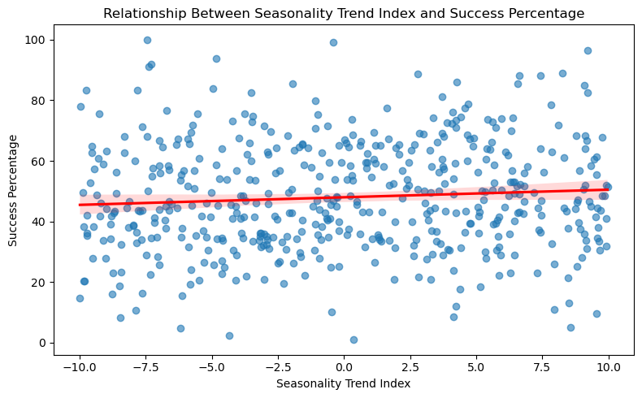

```python
import seaborn as sns
import matplotlib.pyplot as plt
plt.figure(figsize=(8, 5))
sns.regplot(
    data=df,
    x='Seasonality_T',
    y='Success_Percentage',
    scatter_kws={'alpha': 0.6},
    line_kws={'color': 'red'}
)

plt.title('Relationship Between Seasonality Trend Index and Success Percentage')
plt.xlabel('Seasonality Trend Index')
plt.ylabel('Success Percentage')

plt.tight_layout()
plt.show()
```

The scatter plot between "Seasonality_T" and our target feature "Success_Percentage" shows a weak positive relationship. Since the relationship is weak, dropping "Seasonality_T" feature from our supervised machine learning model would be a better decision.

**Dropping "Seasonality_T" feature**

```python
df = df.drop(columns=["Seasonality_T"])
```

```python
print(df.columns.tolist())
```

```
['Category', 'Sub_category', 'Price', 'Rating', 'No_rating', 'Discount', 'M_Spend', 'Supply_Chain_E', 'Sales_y', 'Sales_m', 'Market_T', 'Success_Percentage']
```

### Checking for Outliers

There are two ways we can check outliers for the data. The first way is to generate box plot for each feature to check for outliers and the other way is the Inter-quantile method. first let's check the outliers with the box plot method. In box plot method we will generate box plot for each variable and check for outliers.

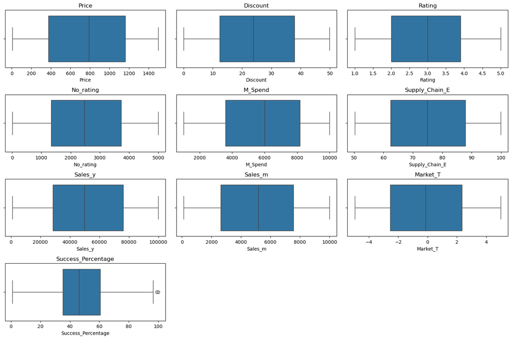

```python
import matplotlib.pyplot as plt
import seaborn as sns

numeric_cols = ['Price', 'Discount', 'Rating', 'No_rating', 'M_Spend', 'Supply_Chain_E',
                'Sales_y', 'Sales_m', 'Market_T', 'Success_Percentage']

plt.figure(figsize=(15, 10))
for i, col in enumerate(numeric_cols):
    plt.subplot(4, 3, i+1)
    sns.boxplot(x=df[col])
    plt.title(col)
plt.tight_layout()
plt.show()
```

In box plots the points outside the whiskers are potential outliers. Observing the box plot of all the features we can see there are no points outside the whiskers except for "Success Percentage" feature. There are two outliers in Success Percentage feature" at 100 percent. This is possible, because it is possible that some product have 100 percent success percentage. Therefore, this is acceptable.

Now, let's check outliers using IQR (Interquartile Range) method and validate our results with box plot method.

```python
def detect_outliers_iqr(data, column):
    Q1 = data[column].quantile(0.25)
    Q3 = data[column].quantile(0.75)
    IQR = Q3 - Q1
    lower_bound = Q1 - 1.5 * IQR
    upper_bound = Q3 + 1.5 * IQR
    outliers = data[(data[column] < lower_bound) | (data[column] > upper_bound)]
    return outliers

numeric_cols = ['Price', 'Discount', 'Rating', 'No_rating', 'M_Spend', 'Supply_Chain_E',
                'Sales_y', 'Sales_m', 'Market_T', 'Success_Percentage']

for col in numeric_cols:
    outliers = detect_outliers_iqr(df, col)
    print(f"{col}: {len(outliers)} outliers")
```

```
Price: 0 outliers
Discount: 0 outliers
Rating: 0 outliers
No_rating: 0 outliers
M_Spend: 0 outliers
Supply_Chain_E: 0 outliers
Sales_y: 0 outliers
Sales_m: 0 outliers
Market_T: 0 outliers
Success_Percentage: 2 outliers
```

The output shows that all the features have no outliers except success percentage feature. there are two outliers in "Success Percentage" feature. It is the same result we got from box plot method, hence validating our earlier result about outliers.

## Data Exploration and Visualisation

### One Variable Plots

#### Histogram of Product Price

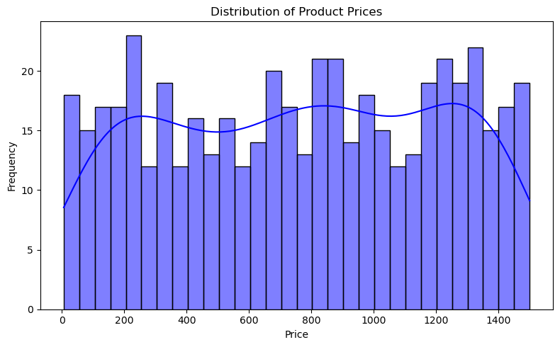

```python
import matplotlib.pyplot as plt
import seaborn as sns
plt.figure(figsize=(8, 5))
sns.histplot(data=df, x='Price', bins=30, kde=True, color='blue')
plt.title('Distribution of Product Prices')
plt.xlabel('Price')
plt.ylabel('Frequency')
plt.tight_layout()
plt.show()
```

The histogram of price distribution shows the distribution of prices across the dataset. The KDE curve helps us to understand the distribution. Observing the KDE curve we now know that the prices are evenly spread, there is no skewness towards low or high prices. However, there is more concentration of product prices between 200 and 1400, indicating presence of mid-range products and premium products.

#### Histogram of Product Rating

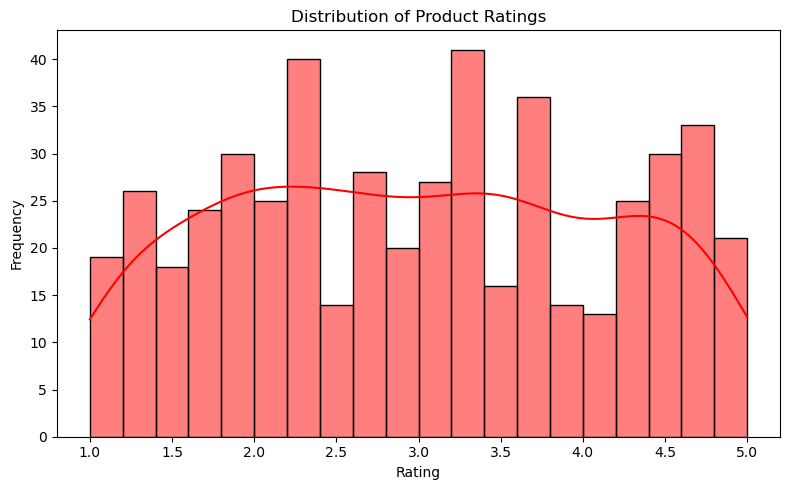

```python
import matplotlib.pyplot as plt
import seaborn as sns
plt.figure(figsize=(8, 5))
sns.histplot(data=df, x='Rating', bins=20, kde=True, color='red')
plt.title('Distribution of Product Ratings')
plt.xlabel('Rating')
plt.ylabel('Frequency')
plt.tight_layout()
plt.show()
```

#### Bar Chart of Category

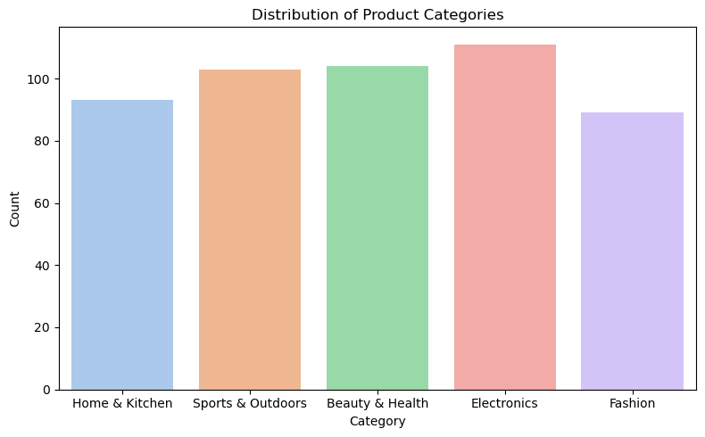

```python
import matplotlib.pyplot as plt
import seaborn as sns
plt.figure(figsize=(8, 5))
sns.countplot(data=df, x='Category', hue='Category', palette='pastel', legend=False)
plt.title('Distribution of Product Categories')
plt.xlabel('Category')
plt.ylabel('Count')
plt.tight_layout()
plt.show()
```

The bar chart for category shows dataset includes products from five major categories:

1. Home and Kitchen
2. Sports and Outdoors
3. Beauty and Health
4. Electronics
5. Fashion

The category Electronics have most products followed by Beauty and Health category. Fashion category has the least number of products.

#### Histogram of Discount

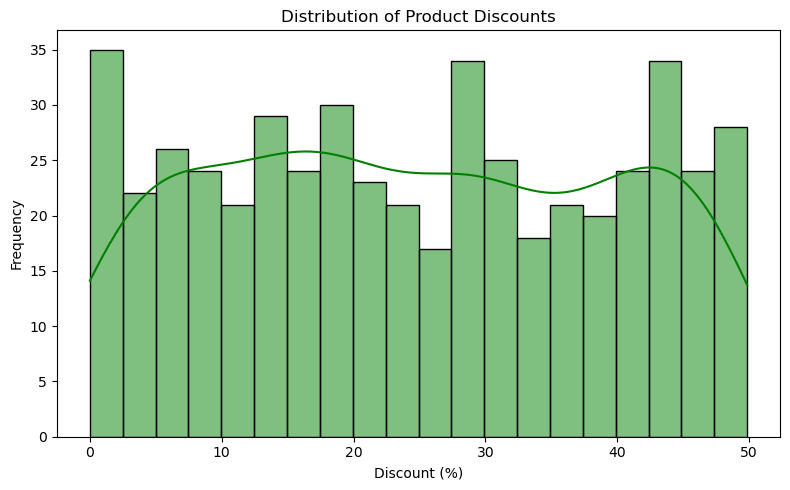

```python
import matplotlib.pyplot as plt
import seaborn as sns
plt.figure(figsize=(8, 5))
sns.histplot(data=df, x='Discount', bins=20, kde=True, color='green')
plt.title('Distribution of Product Discounts')
plt.xlabel('Discount (%)')
plt.ylabel('Frequency')
plt.tight_layout()
plt.show()
```

### Two Variable Plots

#### Scatter Plot for Price vs Success Percentage

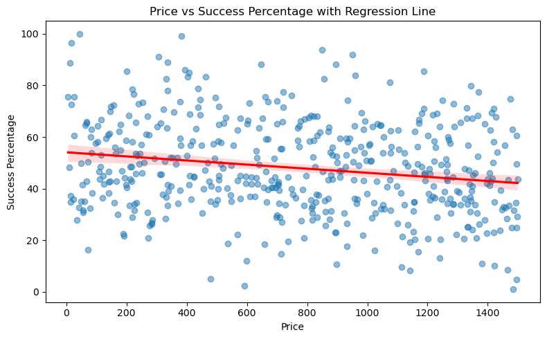

```python
import matplotlib.pyplot as plt
import seaborn as sns
plt.figure(figsize=(8, 5))
sns.regplot(
    data=df,
    x='Price',
    y='Success_Percentage',
    scatter_kws={'alpha': 0.5},
    line_kws={'color': 'red'}
)
plt.title('Price vs Success Percentage with Regression Line')
plt.xlabel('Price')
plt.ylabel('Success Percentage')
plt.tight_layout()
plt.show()
```

The above scatter plot captures the relationship between price of products and success percentage of products. if we look at the red regression line, it is slightly declined indicating a weak negative relationship. As price of products increases their sucess percentage decreases. This gives us an imporatnt insight about costumers. Costumers tend to buy products that are pocket friendly, this directly affects the succes percentage of that product.

#### Scatter Plot for Rating vs Success Percentage

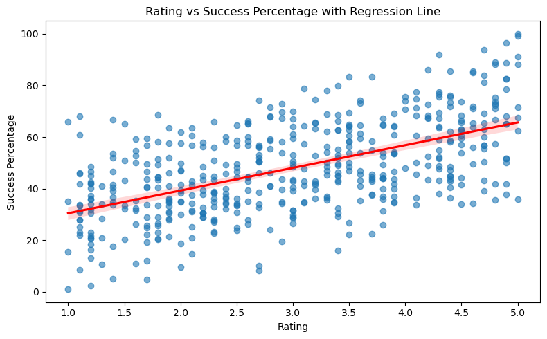

```python
import matplotlib.pyplot as plt
import seaborn as sns
plt.figure(figsize=(8, 5))
sns.regplot(
    data=df,
    x='Rating',
    y='Success_Percentage',
    scatter_kws={'alpha': 0.6},
    line_kws={'color': 'red'}
)
plt.title('Rating vs Success Percentage with Regression Line')
plt.xlabel('Rating')
plt.ylabel('Success Percentage')
plt.tight_layout()
plt.show()
```

The above scatter plot illustrates the relationship between Ratings and success percentage. this shows how ratings affects the success of a product. From the above scatter plot, as the rating increases the success percentage also increases. there is a strong posotive relationship between ratings and success percentage. This concludes that costumers tend to buy products that are highly rated. Before buying a product, checking the ratings of he product is a must for costumers.

#### Scatter Plot for Cost of Marketing vs Yearly Sales

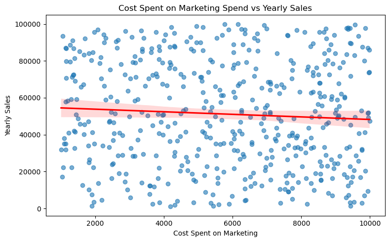

```python
plt.figure(figsize=(8, 5))
sns.regplot(data=df, x='M_Spend', y='Sales_y', scatter_kws={'alpha': 0.6}, line_kws={'color': 'red'})
plt.title('Cost Spent on Marketing Spend vs Yearly Sales')
plt.xlabel('Cost Spent on Marketing')
plt.ylabel('Yearly Sales')
plt.tight_layout()
plt.show()
```

The above scatter plot captures the relationship between cost spent on marketing and yearly sales. intrestingly, there is a weak negative relationship between these two features. this suggests that higher marketing spent does not lead to increased yearly sales in the dataset. the possible reasons can be:

1. Product-market mismatch
2. Possibility that some product categories perform well even with minimal promotion.

#### Box Plot for Yearly Sales by Category

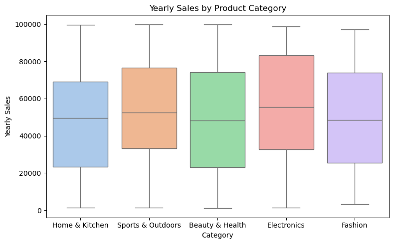

```python
import matplotlib.pyplot as plt
import seaborn as sns
plt.figure(figsize=(8, 5))
sns.boxplot(data=df, x='Category', y='Sales_y', hue='Category', palette='pastel', legend=False)
plt.title('Yearly Sales by Product Category')
plt.xlabel('Category')
plt.ylabel('Yearly Sales')
plt.tight_layout()
plt.show()
```

### Three Variable Plots

#### Price vs Discount by Success Percentage

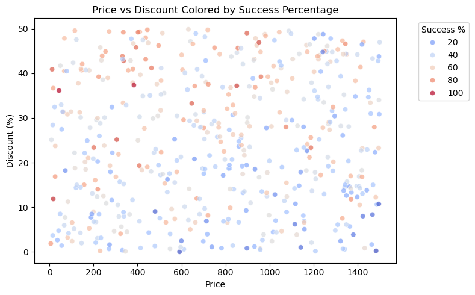

```python
import matplotlib.pyplot as plt
import seaborn as sns

# Create the scatterplot
plt.figure(figsize=(8, 5))
sns.scatterplot(
    data=df,
    x='Price',
    y='Discount',
    hue='Success_Percentage',  # Third variable as color
    palette='coolwarm',        # Color scheme
    alpha=0.7                  # Slight transparency for better visibility
)

# Add labels and title
plt.title('Price vs Discount Colored by Success Percentage')
plt.xlabel('Price')
plt.ylabel('Discount (%)')
plt.legend(title='Success %', bbox_to_anchor=(1.05, 1), loc='upper left')

# Display the plot
plt.tight_layout()
plt.show()
```

#### Number of Rating vs Success Percentage by Category

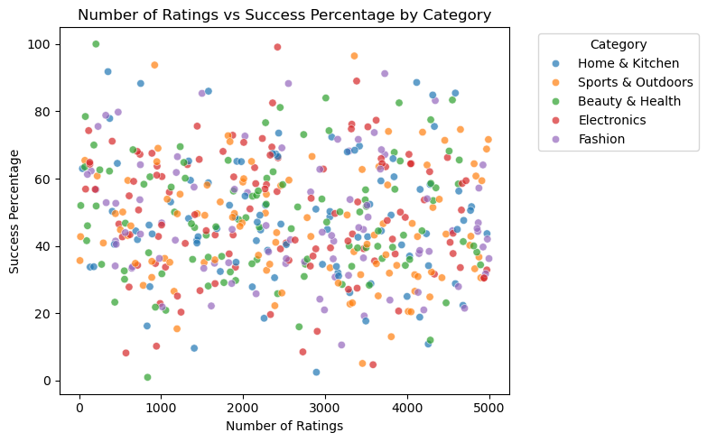

```python
import matplotlib.pyplot as plt
import seaborn as sns

# Scatterplot using three variables: No_rating, Success_Percentage, and Category
plt.figure(figsize=(8, 5))
sns.scatterplot(
    data=df,
    x='No_rating',
    y='Success_Percentage',
    hue='Category',
    alpha=0.7
)

# Add title and axis labels
plt.title('Number of Ratings vs Success Percentage by Category')
plt.xlabel('Number of Ratings')
plt.ylabel('Success Percentage')
plt.legend(title='Category', bbox_to_anchor=(1.05, 1), loc='upper left')

# Show the plot
plt.tight_layout()
plt.show()
```

This plot is a little difficult to interpret, but with a lot of focus and seeing at the success percentage at the Y axis, Number of Ratings at the x axis and Categories in the form of colours, WE can see here that as the number of ratings increase, Fashion, Beauty and health and Home and kitchen success percentage increases. We do not a solid evidence of this finding because the dots for all the categories are well spread. Especially for sports and electronics there are no clear correlations. They are well spread across the grid.

#### Marketing Spend vs Yearly Sales by Success Percentage

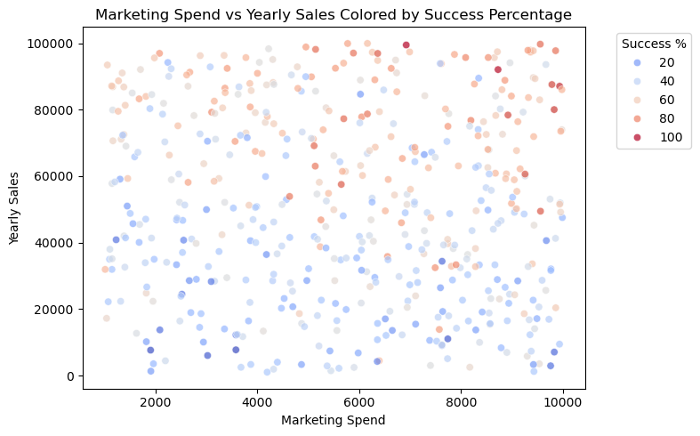

```python
import matplotlib.pyplot as plt
import seaborn as sns
plt.figure(figsize=(8, 5))
sns.scatterplot(
    data=df,
    x='M_Spend',
    y='Sales_y',
    hue='Success_Percentage',
    palette='coolwarm',
    alpha=0.7
)
plt.title('Marketing Spend vs Yearly Sales Colored by Success Percentage')
plt.xlabel('Marketing Spend')
plt.ylabel('Yearly Sales')
plt.legend(title='Success %', bbox_to_anchor=(1.05, 1), loc='upper left')
plt.tight_layout()
plt.show()
```

To make the best understanding of the plot Marketing Spend vs Yearly Sales coloured by successs percentages. I want you to imagine a 4 block virtual grid on top of this plot. This grid is dividing the plot into four portions (Top left, Top right, Bottom left and Bottom right). WE have Marketing spend on the x axis, Yearly sales on the y axis and coloured dots represent the success percentages e.g. blue colours for low percentage and red for high percentage. Common sense says that increase in yearly sales in means that success percentage will increase and Incresae in marketing spend will also increase the success percentage. Looking at the graph and referring to the common sense, we can see the red dots are increasing in the top part because yearly sales are increasing. Looking at the marketing spend and the success percentage we can see the red dots are increasing with the increase in the marketing spend. With this perception, common sense says that the top right block should have the most red dots and they should be dark as well which is clearly visible therefore, increase in the yearly sale snad marketing spend increase the success percentage of the products.

#### Category vs Price by Success Percentage

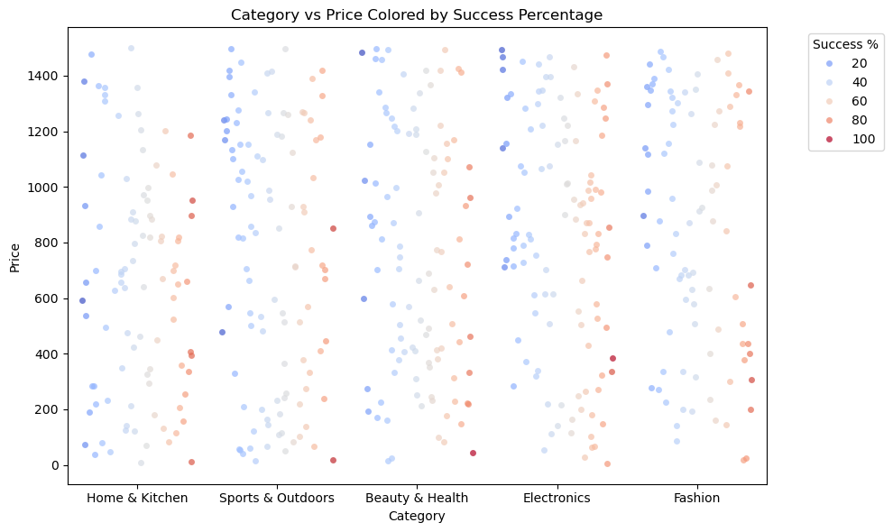

```python
import matplotlib.pyplot as plt
import seaborn as sns
plt.figure(figsize=(10, 6))
sns.stripplot(
    data=df,
    x='Category',
    y='Price',
    hue='Success_Percentage',
    palette='coolwarm',
    dodge=True,
    alpha=0.7,
    jitter=True
)
plt.title('Category vs Price Colored by Success Percentage')
plt.xlabel('Category')
plt.ylabel('Price')
plt.legend(title='Success %', bbox_to_anchor=(1.05, 1), loc='upper left')
plt.tight_layout()
plt.show()
```

For the Category vs Price coloured by success percentage plot ( 3 variable plot). We aim to see that how the Price impacts the success percentage of a product based on the category. The colour scheme here is rather a little deceptive (100% should have been blue or green and 20% should have been red) we could not correct it due to time shortage but we will explain what is happening in detail. If we see the legend, blue colour represents 20% and it turns a little darker towards red colour as we move towards the 100%. We can see in this plot that, for home and kitchen, as the Price of the product in increase the success percentage decreases. For home and kitchen we have the highest difference. We can see a small but similar trend in Sports and outdoor categories; the increase in price sees reduction in success percentage. For other categories including, Beauty and health, Electronics and Fashion we have evidences of similar trends but they are not as prominent as home and kitchen and Sports categories.

## References

1. Shrivastav, U. (n.d.). Product Sales and Marketing Analytics Dataset. Retrieved April 1, 2025, from https://www.kaggle.com/datasets/utkarshshrivastav07/product-sales-and-marketing-analytics-dataset
2. Jing, G., Peng, Q., Zhang, L., Tan, R. and Zhang, J. (2020). Estimation of product success potential using product value. International Journal of Production Research. https://www.tandfonline.com/doi/full/10.1080/00207543.2020.1788733#abstract
3. Shah, D., and Murthi, B.P.S. (2021). Marketing in a data-driven digital world: Implications for the role and scope of marketing. Journal of Business Research. https://www.sciencedirect.com/science/article/abs/pii/S0148296320304355
4. Rosario, A., and Raimundo., R. (2021). Consumer Marketing Strategy and E-Commerce in the Last Decade: A Literature Review. Journal of Theoretical and Applied Electronic Commerece Research. https://www.mdpi.com/0718-1876/16/7/164
5. Tan, W.K. (2023). When do price discounts become attractive? A study comparing discount strategies on consumer perceptions. Asia Pacific Journal of Marketing and Logistics. https://www.emerald.com/insight/content/doi/10.1108/apjml-06-2021-0456/full/html
6. Fan, Z.P., Che, Y,J., Chen, Z,Y. (2017). Product sales forecasting using online reviews and historical sales data: A method combining the Bass model and sentiment analysis. Journal of Business Research. https://www.sciencedirect.com/science/article/abs/pii/S0148296317300231
7. Begum, N. (2024). Big Data Analytics and Its Impact on Customer Behavior Prediction in Retail Businesses. Pacific Journal of Business Innovation and Strategy. https://scienceget.org/index.php/pjbis/article/view/17
8. Smirnov, P.S., and Sudakov, V.A. (1925). Forecasting new product demand using machine learning. Journal of Physics: Conference Series. https://iopscience.iop.org/article/10.1088/1742-6596/1925/1/012033/meta
9. Bataineh, A.Q., Abu-AlSondos, I.A., Frangieh, R.H., Alnajjar, I., and Salameh, A.A. (2024). Predictive Modeling in Marketing Analytics: A Comparative Study of Algorithms and Applications in E-Commerce Sector. Research Gate. https://www.researchgate.net/publication/376851043_Predictive_Modeling_in_Marketing_Analytics_A_Comparative_Study_of_Algorithms_and_Applications_in_E-Commerce_Sector
10. McGinnis, M.A., and Vallopra, R.M. (2006). Purchasing and Supplier Involvement: Issues and Insights Regarding New Product Success. Jornal of Supply Chain Management. https://onlinelibrary.wiley.com/doi/abs/10.1111/j.1745-493X.1999.tb00057.x
11. Hultink, E.J., and Robben, H.S. (1995). Measuring New Product Success: The Difference that Time Perspective Makes. Journal of Product Innovation Management. https://onlinelibrary.wiley.com/doi/abs/10.1111/1540-5885.1250392
12. Sarkar, M., Ayon, E.H., Mia, M.T., Ray, R.k., Chowdhury, M.S., Ghosh, B.P., Al-Imran, M., Islam, M.T., Tayaba, M., and Puja, A.R. (2008, December). Optimizing E-Commerce Profits: A Comprehensive Machine Learning Framework for Dynamic Pricing and Predicting Online Purchases. Journal of Computer Science and Technology Studies. Retrieved from https://www.neliti.com/publications/589846/optimizing-e-commerce-profits-a-comprehensive-machine-learning-framework-for-dyn
13. Vallarino, D. (2023, August). Buy when? Survival machine learning model comparison for purchase timing. Cornell University. Retrieved from https://arxiv.org/abs/2308.14343
14. Gong, C., Zhang, L., Yao,D., Chen, D., Li, W., Su, Y., and Bi, J. (2024, June). CausalMMM: Learning Causal Structure for Marketing Mix Modeling. Cornell University. Retrieved from https://arxiv.org/abs/2406.16728
15. Zhao, X., and Keikhosrokiani, P. (2021, April). Sales Prediction and Product Recommendation Model Through User Behavior Analytics. Computers, Materials and Continua. Retrieved from https://www.techscience.com/cmc/v70n2/44651.
16. S Karsli, K Otto, W Li, A Bilton, K Hölttä-Otto. BARRIERS TO PRODUCT REPAIR: EXPLORING MOTIVATIONS AND CAPABILITIES AMONG OPERATORS. University of Melbourne. Retrieved from https://findanexpert.unimelb.edu.au/scholarlywork/1951860-barriers-to-product-repair--exploring-motivations-and-capabilities-among-operators?cache=1733640278302